# Phylogenetics in R

Pol dataset

Louis du Plessis

Last modified: 22 Jun 2026

# Pol dataset

First we read in the alignments.

```r
pol <- read.dna(params$polfile, format = "fasta")
```

We can check to see that pol contains 42 sequences of length 689. We can also display the names of the sequences contained in each.

We also extract the names of the sequences that stem from the patient, the victim, and the community.

```r
pol
```

```
## 42 DNA sequences in binary format stored in a matrix.
##
## All sequences of same length: 689
##
## Labels:
## AY156771.1|LA02.RT
## AY156793.1|LA30.RT
## AY156783.1|LA18.RT
## AY156778.1|LA12.RT
## AY156792.1|LA29.RT
## AY156773.1|LA05.RT
## ...
##
## Base composition:
##     a     c     g     t
## 0.407 0.164 0.196 0.232
## (Total: 28.94 kb)
```

```r
labels(pol)
```

```
##  [1] "AY156771.1|LA02.RT "   "AY156793.1|LA30.RT "   "AY156783.1|LA18.RT "
##  [4] "AY156778.1|LA12.RT "   "AY156792.1|LA29.RT "   "AY156773.1|LA05.RT "
##  [7] "AY156795.1|LA32.RT "   "AY156775.1|LA07.RT "   "AY156774.1|LA06.RT "
## [10] "AY156791.1|LA28.RT "   "AY156776.1|LA08.RT "   "AY156786.1|LA23.RT "
## [13] "AY156789.1|LA26.RT "   "AY156785.1|LA22.RT "   "AY156788.1|LA25.RT "
## [16] "AY156790.1|LA27.RT "   "AY156779.1|LA13.RT "   "AY156780.1|LA14.RT "
## [19] "AY156781.1|LA16.RT "   "AY156782.1|LA17.RT "   "AY156799.1|P2.MIC.RT "
## [22] "AY156797.1|P1.MIC.RT " "AY156735.1|P2.BCM.RT " "AY156800.1|P3.MIC.RT "
## [25] "AY156802.1|P5.MIC.RT " "AY156737.1|P4.BCM.RT " "AY156740.1|P7.BCM.RT "
## [28] "AY156734.1|P1.BCM.RT " "AY156739.1|P6.BCM.RT " "AY156806.1|V1.MIC.RT "
## [31] "AY156807.1|V2.MIC.RT " "AY156803.1|P6.MIC.RT " "AY156738.1|P5.BCM.RT "
## [34] "AY156741.1|V1.BCM.RT " "AY156742.1|V2.BCM.RT " "AY156736.1|P3.BCM.RT "
## [37] "AY156801.1|P4.MIC.RT " "AY156784.1|LA21.RT "   "AY156787.1|LA24.RT "
## [40] "AY156777.1|LA10.RT "   "AY156772.1|LA04.RT "   "AY156794.1|LA31.RT "
```

```r
allpatients_pol <- sapply(strsplit(labels(pol), "\\|"), function(x) x[2])
patient_pol     <- labels(pol)[grep("^P", allpatients_pol)]
victim_pol      <- labels(pol)[grep("^V", allpatients_pol)]
community_pol   <- labels(pol)[grep("^LA", allpatients_pol)]
```

## Distance-based trees

Calculate a neighbour-joining tree using a TN93 substitution model.

```r
D_pol_TN93 <- ape::dist.dna(pol, model="TN93", as.matrix=TRUE)
tree_pol_NJ_TN93 <- phangorn::NJ(D_pol_TN93)
```

Check if the tree is rooted and if not, plot the unrooted tree.

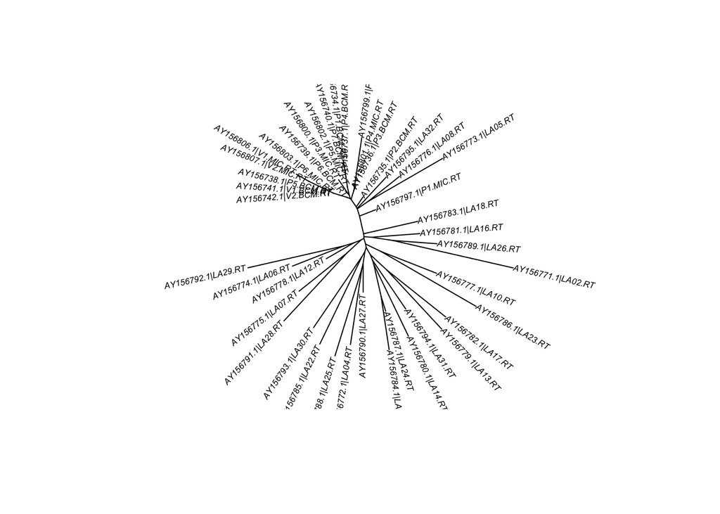

```r
if (!is.rooted(tree_pol_NJ_TN93)) {
    ape::plot.phylo(tree_pol_NJ_TN93, type = "unrooted", cex=0.5, lab4ut = "axial")
}
```

We assume the outgroup is `AY156771.1|LA02.RT` (one of the community sequences) and root the neighbour-joining tree on it, before plotting the rooted tree.

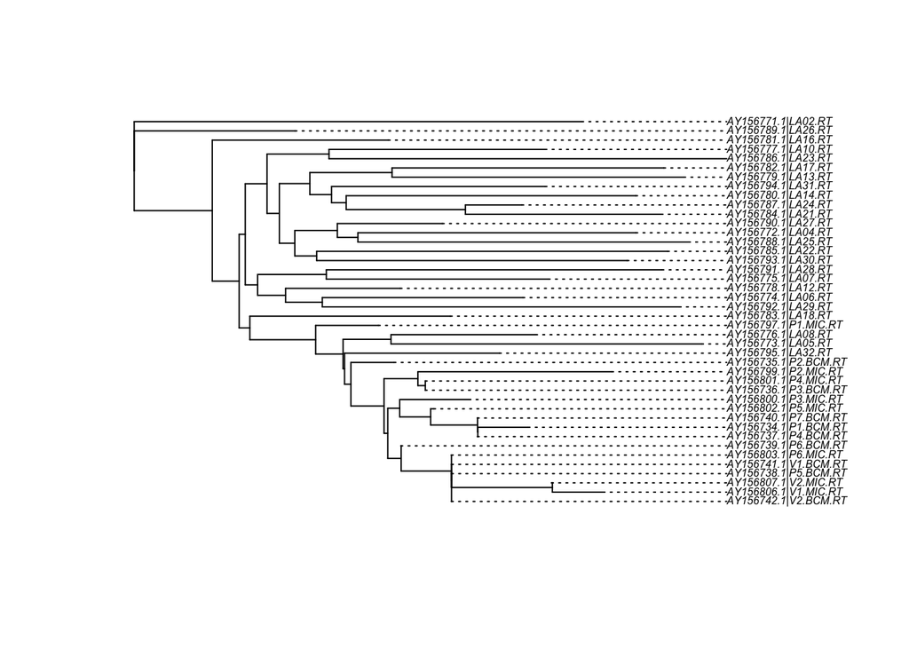

```r
  tree_pol_NJ_TN93_rooted <- root.phylo(tree_pol_NJ_TN93,
                                        outgroup = "AY156771.1|LA02.RT ",
                                        resolve.root = TRUE)
  plot.phylo(tree_pol_NJ_TN93_rooted, align.tip.label = TRUE, cex=0.5)
```

Now create a colour array to colour patient, victim and community sequences differently using the `tip.color` argument in `plot.phylo()`.

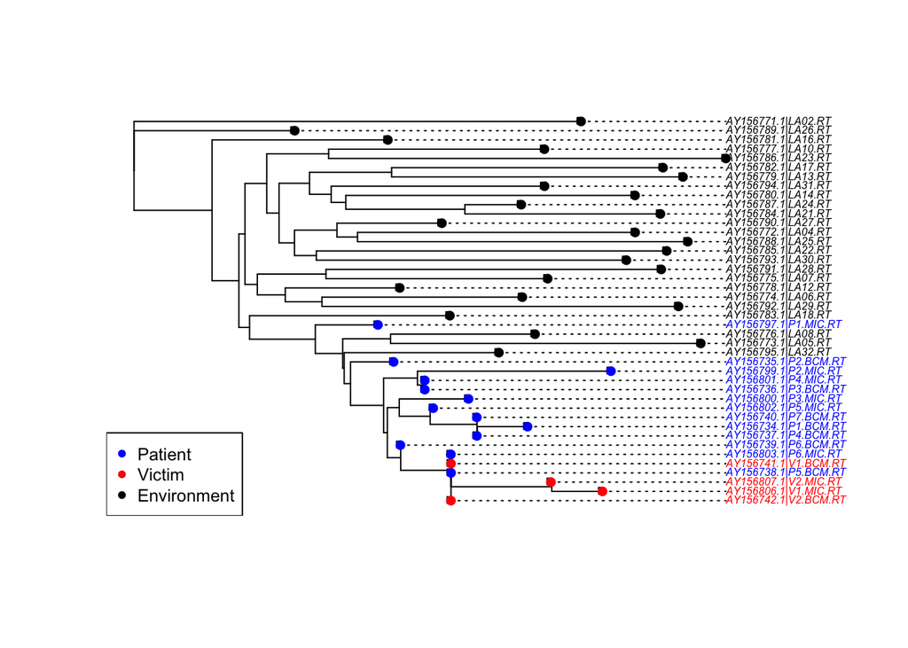

```r
    colours <- rep("black", length(allpatients_pol))
    colours[match(patient_pol, tree_pol_NJ_TN93_rooted$tip.label)] <- 'blue'
    colours[match(victim_pol, tree_pol_NJ_TN93_rooted$tip.label)] <- 'red'

    plot.phylo(tree_pol_NJ_TN93_rooted, align.tip.label = TRUE, cex=0.5,
               tip.color = colours)
    tiplabels(NA, pch=16, col=colours)
    legend("bottomleft", legend=c("Patient", "Victim", "Environment"),
           col=c("blue", "red", "black"), pch=16, cex=0.8)
```

Build the neighbour-joining tree using a Jukes-Cantor model, plot the tree and then plot the tanglegram connecting the Jukes Cantor NJ tree to the TN93 NJ tree.

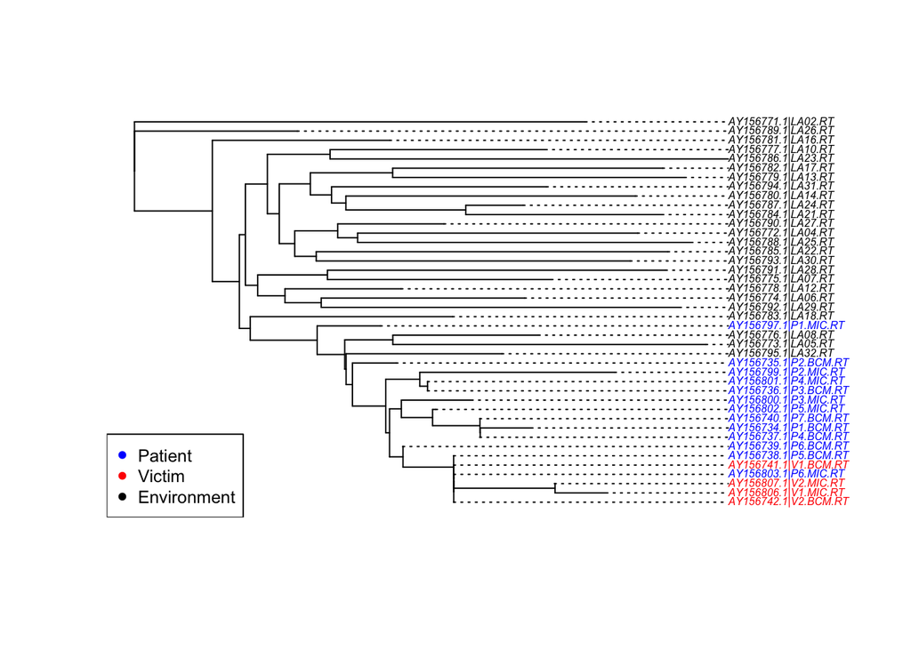

```r
# Construct and root Neighbour-joining tree
D_pol_JC <- ape::dist.dna(pol, model="JC", as.matrix=TRUE)
tree_pol_NJ_JC <- phangorn::NJ(D_pol_JC)
tree_pol_NJ_JC_rooted <- root.phylo(tree_pol_NJ_JC,
                                    outgroup = "AY156771.1|LA02.RT ",
                                    resolve.root = TRUE)

# Plot the tree
plot.phylo(tree_pol_NJ_JC_rooted, align.tip.label = TRUE, cex=0.5,
           tip.color = colours)
legend("bottomleft", legend=c("Patient", "Victim", "Environment"),
           col=c("blue", "red", "black"), pch=16, cex=0.8)
```

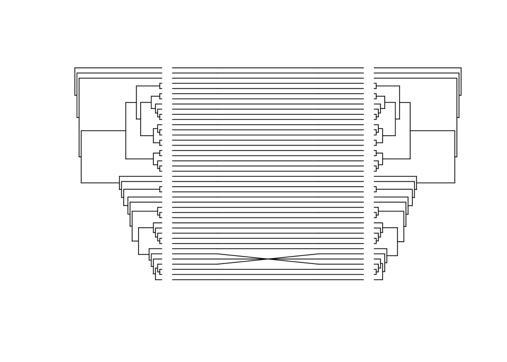

```r
# Plot the tanglegram
cophyloplot(tree_pol_NJ_JC_rooted, tree_pol_NJ_TN93_rooted, assoc=cbind(tree_pol_NJ_JC_rooted$tip.label, tree_pol_NJ_TN93_rooted$tip.label), show.tip.label = FALSE, space=100, gap =5, length.line=0.2)
```

## Parsimony

Calculate the parsimony score of the NJ tree. To use the function we have to first convert the alignment to an object of type `phyDat`, which is used by the `phangorn` package.

```r
  pol_phyDat <- as.phyDat(pol)
  parsimony(tree_pol_NJ_JC, pol_phyDat)
```

```
## [1] 398
```

Now use the `pratchet()` function to find the maximum parsimony tree and then use `acctran()` to adjust the branch lengths, and again plot the tree.

```r
  # Calculate the maximum parsimony tree
  tree_pol_MP <- pratchet(pol_phyDat)
```

```
## Parsimony score of initial tree: 369
## Iteration: 10. Best parsimony score so far: 366Iteration: 20. Best parsimony score so far: 366Iteration: 30. Best parsimony score so far: 366Iteration: 40. Best parsimony score so far: 366Iteration: 50. Best parsimony score so far: 366Iteration: 60. Best parsimony score so far: 366Iteration: 70. …
```

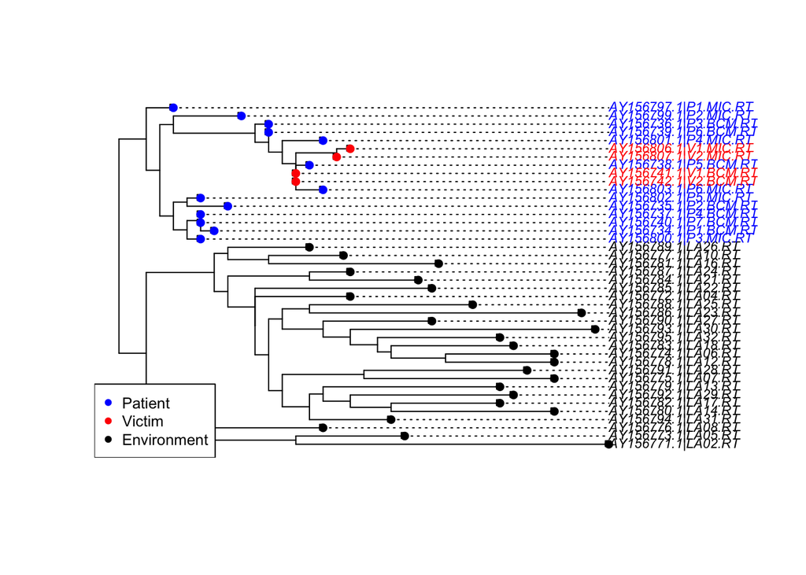

```r
  tree_pol_MP <- acctran(tree_pol_MP, data = pol_phyDat)

  # Plot it
  colours <- rep("black", length(tree_pol_MP$tip.label))
  colours[match(patient_pol, tree_pol_MP$tip.label)] <- 'blue'
  colours[match(victim_pol, tree_pol_MP$tip.label)] <- 'red'

  plot.phylo(tree_pol_MP, align.tip.label = TRUE, cex=0.7,
               tip.color = colours)
  tiplabels(NA, pch=16, col=colours)
  legend("bottomleft", legend=c("Patient", "Victim", "Environment"),
       col=c("blue", "red", "black"), pch=16, cex=0.8)
```

```r
  parsimony(tree_pol_NJ_TN93, pol_phyDat)
```

```
## [1] 398
```

```r
  parsimony(tree_pol_MP, pol_phyDat)
```

```
## [1] 366
```

```r
  parsimony(tree_pol_NJ_TN93, pol_phyDat) < parsimony(tree_pol_MP, pol_phyDat)
```

```
## [1] FALSE
```

Now we plot the tanglegram comparing the neighbour-joining tree to the maximum parsimony tree.

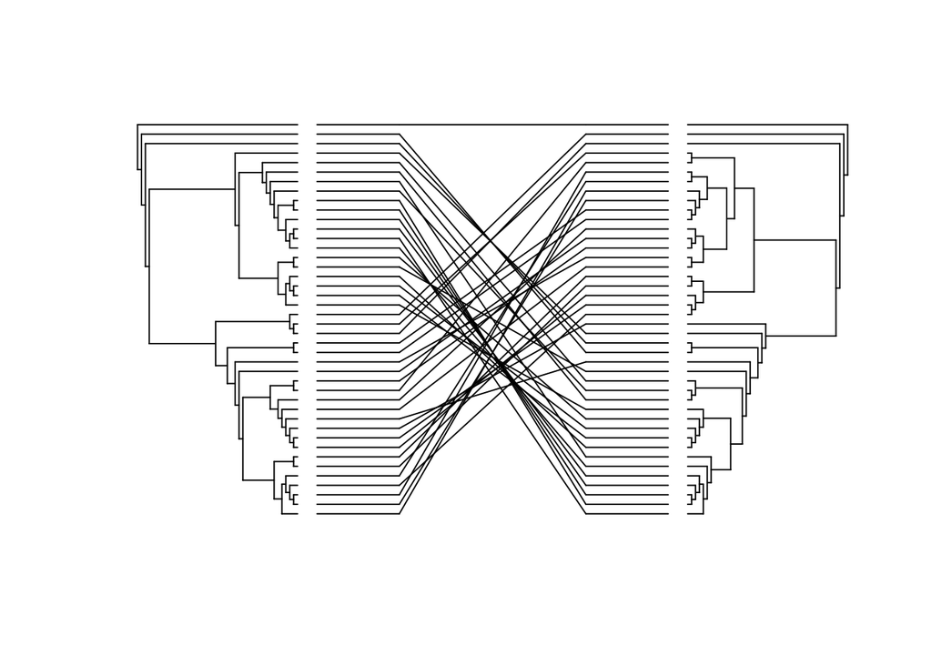

```r
  # Root on the same sequence
  tree_pol_MP_rooted <- root.phylo(tree_pol_MP,
                                   outgroup = "AY156771.1|LA02.RT ",
                                   resolve.root = TRUE)

  # Plot the tanglegram
  cophyloplot(tree_pol_MP_rooted, tree_pol_NJ_TN93_rooted,
              assoc=cbind(tree_pol_MP_rooted$tip.label,
                          tree_pol_NJ_TN93_rooted$tip.label),
              show.tip.label = FALSE, space=100, gap =5, length.line=0.1)
```